# Project: Investigate a Dataset (Gapminder World)

- Introduction
- Data Wrangling
- Exploratory Data Analysis
- Conclusions

## Introduction

##### In this project, I used datasets from Gapminder data world to analyze the countries performance in (Economy ,Health, and Social fields)

##### ,i used 4 independent variables and 1 dependent variable to evaluate that performance. i will choose the last to decades (2000-2018) to analyze

##### 1- independent variables :

- Total population
- Life expectancy
- GDP per Capita (a country's economic output per person) GDP/Total population
- Health per GDP (percentage of health expenditure to GDP) this data wasn't updated in gapminder so i get it from WHO data (https://apps.who.int/nha/database/Select/Indicators/en)

##### 2-Dependent variable:

- Happiness score

##### Questions i will answers from this analysis:

- 1-which is the heighest continent performance in each indicator ?
- 2- which are Top 10 performance countries in each indicator?
- 3- which are Bottom 10 performance countries ?
- 4- How is Egypt performance in each indicator over years?
- 5- is there any correlation between indicators?
- 6- by income level is there any changes in number of countries in each level ? or any increase in number of countries that gone from low to middel or high income?
- 7- after spotting highest countries performance choose one to analyse it in details
- 8- what is the indicator that have the bigest impact on happiness score?

```python
#importing all packages i will use in my analysis

import pandas as pd
import numpy as np
import matplotlib.pyplot as plt
%matplotlib inline
import seaborn as sns
```

```python
# code to display dataframs side by side in jupyter (source: Stackoverflow )

from IPython.core.display import display, HTML

def display_side_by_side(dfs:list, captions:list):
    """Display tables side by side to save vertical space
    Input:
        dfs: list of pandas.DataFrame
        captions: list of table captions
    """
    output = ""
    combined = dict(zip(captions, dfs))
    for caption, df in combined.items():
        output += df.style.set_table_attributes("style='display:inline'").set_caption(caption)._repr_html_()
        output += "\xa0\xa0\xa0"
    display(HTML(output))
```

## Data wrangling

### Data for indicator 1 (Life expectancy)

```python
#importing data sets 1 indicator life expectancy

life_exp=pd.read_csv("life_expectancy_years.csv")
```

```python
## assecing data
life_exp.head()
```

|  | country | 1800 | 1801 | 1802 | 1803 | 1804 | 1805 | 1806 | 1807 | 1808 | ... | 2091 | 2092 | 2093 | 2094 | 2095 | 2096 | 2097 | 2098 | 2099 | 2100 |
| --- | --- | --- | --- | --- | --- | --- | --- | --- | --- | --- | --- | --- | --- | --- | --- | --- | --- | --- | --- | --- | --- |
| 0 | Afghanistan | 28.2 | 28.2 | 28.2 | 28.2 | 28.2 | 28.2 | 28.1 | 28.1 | 28.1 | ... | 76.5 | 76.6 | 76.7 | 76.9 | 77.0 | 77.1 | 77.3 | 77.4 | 77.5 | 77.7 |
| 1 | Angola | 27.0 | 27.0 | 27.0 | 27.0 | 27.0 | 27.0 | 27.0 | 27.0 | 27.0 | ... | 78.7 | 78.9 | 79.0 | 79.1 | 79.3 | 79.4 | 79.5 | 79.7 | 79.8 | 79.9 |
| 2 | Albania | 35.4 | 35.4 | 35.4 | 35.4 | 35.4 | 35.4 | 35.4 | 35.4 | 35.4 | ... | 87.4 | 87.5 | 87.6 | 87.7 | 87.8 | 87.9 | 88.0 | 88.1 | 88.2 | 88.3 |
| 3 | Andorra | NaN | NaN | NaN | NaN | NaN | NaN | NaN | NaN | NaN | ... | NaN | NaN | NaN | NaN | NaN | NaN | NaN | NaN | NaN | NaN |
| 4 | United Arab Emirates | 30.7 | 30.7 | 30.7 | 30.7 | 30.7 | 30.7 | 30.7 | 30.7 | 30.7 | ... | 82.1 | 82.2 | 82.3 | 82.4 | 82.5 | 82.6 | 82.7 | 82.8 | 82.9 | 83.0 |

5 rows × 302 columns

```python
#slicing data using numpay and iloc to choose the data from 2000 to 2018 this is period i need to analyze

life_exp2=life_exp.iloc[:,np.r_[:1,201:220]]

life_exp2.head()
```

|  | country | 2000 | 2001 | 2002 | 2003 | 2004 | 2005 | 2006 | 2007 | 2008 | 2009 | 2010 | 2011 | 2012 | 2013 | 2014 | 2015 | 2016 | 2017 | 2018 |
| --- | --- | --- | --- | --- | --- | --- | --- | --- | --- | --- | --- | --- | --- | --- | --- | --- | --- | --- | --- | --- |
| 0 | Afghanistan | 54.6 | 54.8 | 55.6 | 56.4 | 56.9 | 57.4 | 57.6 | 58.0 | 58.8 | 59.3 | 59.9 | 60.4 | 60.8 | 61.3 | 61.2 | 61.2 | 61.2 | 63.4 | 63.7 |
| 1 | Angola | 51.7 | 52.4 | 53.5 | 54.2 | 54.8 | 55.7 | 56.4 | 57.5 | 58.4 | 59.1 | 59.9 | 60.6 | 61.3 | 61.9 | 62.8 | 63.3 | 63.8 | 64.2 | 64.6 |
| 2 | Albania | 74.9 | 75.2 | 75.3 | 75.4 | 75.6 | 76.0 | 76.4 | 76.9 | 77.0 | 77.5 | 77.6 | 77.7 | 77.8 | 77.9 | 77.9 | 78.0 | 78.1 | 78.2 | 78.3 |
| 3 | Andorra | 81.2 | 81.4 | 81.6 | 81.7 | 81.7 | 81.8 | 82.0 | 82.1 | 82.2 | 82.2 | 82.3 | 82.4 | 82.4 | 82.5 | 82.5 | 82.6 | 82.7 | 82.7 | NaN |
| 4 | United Arab Emirates | 71.8 | 71.8 | 72.1 | 72.0 | 72.0 | 72.5 | 72.6 | 72.6 | 72.8 | 72.9 | 72.9 | 72.9 | 72.9 | 73.0 | 73.1 | 73.1 | 73.2 | 73.3 | 73.5 |

```python
#exploring data info
life_exp2.info()
```

```
<class 'pandas.core.frame.DataFrame'>
RangeIndex: 189 entries, 0 to 188
Data columns (total 20 columns):
 #   Column   Non-Null Count  Dtype
---  ------   --------------  -----
 0   country  189 non-null    object
 1   2000     189 non-null    float64
 2   2001     189 non-null    float64
 3   2002     189 non-null    float64
 4   2003     189 non-null    float64
 5   2004     189 non-null    float64
 6   2005     189 non-null    float64
 7   2006     189 non-null    float64
 8   2007     189 non-null    float64
 9   2008     189 non-null    float64
 10  2009     189 non-null    float64
 11  2010     189 non-null    float64
 12  2011     189 non-null    float64
 13  2012     189 non-null    float64
 14  2013     189 non-null    float64
 15  2014     189 non-null    float64
 16  2015     189 non-null    float64
 17  2016     189 non-null    float64
 18  2017     189 non-null    float64
 19  2018     186 non-null    float64
dtypes: float64(19), object(1)
memory usage: 29.7+ KB
```

It is look like there is null data need to be completed so i will complete it with ffill from the previous year data

```python
life_exp2=life_exp2.ffill(axis=1)

life_exp2.isnull().any().sum()
```

```
0
```

check if there is any duplicated rows

```python
sum(life_exp2.duplicated())
```

```
0
```

```python
## using melt() pandas method to convert data from wide to long to be more easily to analyze and manipulate

life_exp_final=life_exp2.melt(id_vars="country",var_name="year",value_name="life_expectancy")
life_exp_final.head()
```

|  | country | year | life_expectancy |
| --- | --- | --- | --- |
| 0 | Afghanistan | 2000 | 54.6 |
| 1 | Angola | 2000 | 51.7 |
| 2 | Albania | 2000 | 74.9 |
| 3 | Andorra | 2000 | 81.2 |
| 4 | United Arab Emirates | 2000 | 71.8 |

```python
##sorting our data in ascending order to be more tidious

life_exp_final.sort_values(["country","year"],inplace=True)
life_exp_final.head()
```

|  | country | year | life_expectancy |
| --- | --- | --- | --- |
| 0 | Afghanistan | 2000 | 54.6 |
| 189 | Afghanistan | 2001 | 54.8 |
| 378 | Afghanistan | 2002 | 55.6 |
| 567 | Afghanistan | 2003 | 56.4 |
| 756 | Afghanistan | 2004 | 56.9 |

```python
## checking data type and modifying

life_exp_final=life_exp_final.astype({"year":"int64","life_expectancy":"float64"},copy=True)

life_exp_final.dtypes
```

```
country             object
year                 int64
life_expectancy    float64
dtype: object
```

### Data for 2nd indicator (Total population)

```python
total_population=pd.read_csv("population_total.csv")
```

```python
# inspecting the data

total_population.head()
```

|  | country | 1800 | 1801 | 1802 | 1803 | 1804 | 1805 | 1806 | 1807 | 1808 | ... | 2091 | 2092 | 2093 | 2094 | 2095 | 2096 | 2097 | 2098 | 2099 | 2100 |
| --- | --- | --- | --- | --- | --- | --- | --- | --- | --- | --- | --- | --- | --- | --- | --- | --- | --- | --- | --- | --- | --- |
| 0 | Afghanistan | 3.28M | 3.28M | 3.28M | 3.28M | 3.28M | 3.28M | 3.28M | 3.28M | 3.28M | ... | 76.6M | 76.4M | 76.3M | 76.1M | 76M | 75.8M | 75.6M | 75.4M | 75.2M | 74.9M |
| 1 | Angola | 1.57M | 1.57M | 1.57M | 1.57M | 1.57M | 1.57M | 1.57M | 1.57M | 1.57M | ... | 168M | 170M | 172M | 175M | 177M | 179M | 182M | 184M | 186M | 188M |
| 2 | Albania | 400k | 402k | 404k | 405k | 407k | 409k | 411k | 413k | 414k | ... | 1.33M | 1.3M | 1.27M | 1.25M | 1.22M | 1.19M | 1.17M | 1.14M | 1.11M | 1.09M |
| 3 | Andorra | 2650 | 2650 | 2650 | 2650 | 2650 | 2650 | 2650 | 2650 | 2650 | ... | 63k | 62.9k | 62.9k | 62.8k | 62.7k | 62.7k | 62.6k | 62.5k | 62.5k | 62.4k |
| 4 | United Arab Emirates | 40.2k | 40.2k | 40.2k | 40.2k | 40.2k | 40.2k | 40.2k | 40.2k | 40.2k | ... | 12.3M | 12.4M | 12.5M | 12.5M | 12.6M | 12.7M | 12.7M | 12.8M | 12.8M | 12.9M |

5 rows × 302 columns

```python
#slicing the data to get the targeted years range (2000 to 2018)

total_population=total_population.iloc[:,np.r_[:1,201:220]]
```

```python
total_population.info()
```

```
<class 'pandas.core.frame.DataFrame'>
RangeIndex: 197 entries, 0 to 196
Data columns (total 20 columns):
 #   Column   Non-Null Count  Dtype
---  ------   --------------  -----
 0   country  197 non-null    object
 1   2000     197 non-null    object
 2   2001     197 non-null    object
 3   2002     197 non-null    object
 4   2003     197 non-null    object
 5   2004     197 non-null    object
 6   2005     197 non-null    object
 7   2006     197 non-null    object
 8   2007     197 non-null    object
 9   2008     197 non-null    object
 10  2009     197 non-null    object
 11  2010     197 non-null    object
 12  2011     197 non-null    object
 13  2012     197 non-null    object
 14  2013     197 non-null    object
 15  2014     197 non-null    object
 16  2015     197 non-null    object
 17  2016     197 non-null    object
 18  2017     197 non-null    object
 19  2018     197 non-null    object
dtypes: object(20)
memory usage: 30.9+ KB
```

it is look like the data do not have any null values

```python
sum(total_population.duplicated())
```

```
0
```

NO duplicated values also Good!!

```python
# now i will convert the data from wide to long

total_population2=pd.melt(total_population,id_vars="country",var_name="year",value_name="total_population")

total_population2.head(10)
```

|  | country | year | total_population |
| --- | --- | --- | --- |
| 0 | Afghanistan | 2000 | 20.8M |
| 1 | Angola | 2000 | 16.4M |
| 2 | Albania | 2000 | 3.13M |
| 3 | Andorra | 2000 | 65.4k |
| 4 | United Arab Emirates | 2000 | 3.13M |
| 5 | Argentina | 2000 | 36.9M |
| 6 | Armenia | 2000 | 3.07M |
| 7 | Antigua and Barbuda | 2000 | 76k |
| 8 | Australia | 2000 | 19M |
| 9 | Austria | 2000 | 8.07M |

```python
#it looks like there is a serious dirty data here i will extract data value from a string and converting it to int

pop_num=[]

for x in total_population2.total_population:
    if x[-1]=="M":
        x=x.replace("M","")
        f=float(x)
        pop_num.append(f*1000000)
    elif x[-1]=="k":
        x=x.replace("k","")
        f=float(x)
        pop_num.append(f*1000)

    elif x[-1]=="B":
        x=x.replace("B","")
        f=float(x)
        pop_num.append(f*1000000000)
    else:
        f=float(x)
        pop_num.append(f)

total_population2["total_population"]=pop_num
```

```python
# converting data types
total_population2=total_population2.astype({"year":"int64","total_population":"int64"},copy=True)
```

```python
#checking data type
total_population2.dtypes
```

```
country             object
year                 int64
total_population     int64
dtype: object
```

```python
# sorting data by country and year

total_population2=total_population2.sort_values(["country","year"])
```

```python
total_population2.head()
```

|  | country | year | total_population |
| --- | --- | --- | --- |
| 0 | Afghanistan | 2000 | 20800000 |
| 197 | Afghanistan | 2001 | 21600000 |
| 394 | Afghanistan | 2002 | 22600000 |
| 591 | Afghanistan | 2003 | 23700000 |
| 788 | Afghanistan | 2004 | 24700000 |

### Data for indicator 3(total_health_spending(% of gdp)

```python
health_expenditure=pd.read_csv("health.csv")
```

```python
# assessing data
health_expenditure.head()
```

|  | country | year | health_per_gdp |
| --- | --- | --- | --- |
| 0 | Afghanistan | 2000 | 9.667514 |
| 1 | Albania | 2000 | 7.233370 |
| 2 | Algeria | 2000 | 3.489033 |
| 3 | Andorra | 2000 | 5.889903 |
| 4 | Angola | 2000 | 1.908599 |

```python
## rounding health per gdp data to nearest 2 decimal numbers
health_expenditure=health_expenditure.round(2)
```

```python
#checking if there is any null values

health_expenditure.isnull().any()
```

```
country           False
year              False
health_per_gdp    False
dtype: bool
```

```python
#checking any duplicate values

health_expenditure.duplicated().sum()
```

```
0
```

```python
#checking the datatypes

health_expenditure.dtypes
```

```
country            object
year                int64
health_per_gdp    float64
dtype: object
```

```python
health_expenditure.info()
```

```
<class 'pandas.core.frame.DataFrame'>
RangeIndex: 3648 entries, 0 to 3647
Data columns (total 3 columns):
 #   Column          Non-Null Count  Dtype
---  ------          --------------  -----
 0   country         3648 non-null   object
 1   year            3648 non-null   int64
 2   health_per_gdp  3648 non-null   float64
dtypes: float64(1), int64(1), object(1)
memory usage: 85.6+ KB
```

```python
health_expenditure.head()
```

|  | country | year | health_per_gdp |
| --- | --- | --- | --- |
| 0 | Afghanistan | 2000 | 9.67 |
| 1 | Albania | 2000 | 7.23 |
| 2 | Algeria | 2000 | 3.49 |
| 3 | Andorra | 2000 | 5.89 |
| 4 | Angola | 2000 | 1.91 |

### dataset for indicator 4 (GDP per Capita)

```python
gdp_per_capita=pd.read_csv("gdp_per_capita.csv")
```

```python
#assessing data
gdp_per_capita.head()
```

|  | country | 1800 | 1801 | 1802 | 1803 | 1804 | 1805 | 1806 | 1807 | 1808 | ... | 2031 | 2032 | 2033 | 2034 | 2035 | 2036 | 2037 | 2038 | 2039 | 2040 |
| --- | --- | --- | --- | --- | --- | --- | --- | --- | --- | --- | --- | --- | --- | --- | --- | --- | --- | --- | --- | --- | --- |
| 0 | Afghanistan | 603 | 603 | 603 | 603 | 603 | 603 | 603 | 603 | 603 | ... | 2550 | 2600 | 2660 | 2710 | 2770 | 2820 | 2880 | 2940 | 3000 | 3060 |
| 1 | Angola | 618 | 620 | 623 | 626 | 628 | 631 | 634 | 637 | 640 | ... | 6110 | 6230 | 6350 | 6480 | 6610 | 6750 | 6880 | 7020 | 7170 | 7310 |
| 2 | Albania | 667 | 667 | 667 | 667 | 667 | 668 | 668 | 668 | 668 | ... | 19.4k | 19.8k | 20.2k | 20.6k | 21k | 21.5k | 21.9k | 22.3k | 22.8k | 23.3k |
| 3 | Andorra | 1200 | 1200 | 1200 | 1200 | 1210 | 1210 | 1210 | 1210 | 1220 | ... | 73.6k | 75.1k | 76.7k | 78.3k | 79.8k | 81.5k | 83.1k | 84.8k | 86.5k | 88.3k |
| 4 | United Arab Emirates | 998 | 1000 | 1010 | 1010 | 1010 | 1020 | 1020 | 1020 | 1030 | ... | 66.8k | 68.1k | 69.4k | 70.8k | 72.2k | 73.7k | 75.2k | 76.7k | 78.3k | 79.9k |

5 rows × 242 columns

```python
#slicing data to get targeted period (2000-2018)

gdp_per_capita=gdp_per_capita.iloc[:,np.r_[:1,201:220]]
```

```python
#checking for any null values
gdp_per_capita.isnull().any().sum()
```

```
0
```

```python
#checking for any duplicated values

gdp_per_capita.duplicated().sum()
```

```
0
```

```python
# converting data from wide to long to be easily manipulated

gdp_per_capita2=gdp_per_capita.melt(id_vars="country",var_name="year",value_name="gdp_per_capita")
```

```python
gdp_per_capita2.head()
```

|  | country | year | gdp_per_capita |
| --- | --- | --- | --- |
| 0 | Afghanistan | 2000 | 687 |
| 1 | Angola | 2000 | 3890 |
| 2 | Albania | 2000 | 5440 |
| 3 | Andorra | 2000 | 31.7k |
| 4 | United Arab Emirates | 2000 | 103k |

```python
# checking for data types
gdp_per_capita2.dtypes
```

```
country           object
year              object
gdp_per_capita    object
dtype: object
```

```python
#extracting values from string


gdp_num=[]

for x in gdp_per_capita2.gdp_per_capita:

    if x[-1]=="k":
        x=x.replace("k","")
        f=float(x)
        gdp_num.append(f*1000)
    else:
        f=float(x)
        gdp_num.append(f)

gdp_per_capita2["gdp_per_capita"]=gdp_num
```

```python
#changing the datatype

gdp_per_capita2=gdp_per_capita2.astype({"year":"int64","gdp_per_capita":"int64"},copy=True)
```

```python
gdp_per_capita2.info()
```

```
<class 'pandas.core.frame.DataFrame'>
RangeIndex: 3705 entries, 0 to 3704
Data columns (total 3 columns):
 #   Column          Non-Null Count  Dtype
---  ------          --------------  -----
 0   country         3705 non-null   object
 1   year            3705 non-null   int64
 2   gdp_per_capita  3705 non-null   int64
dtypes: int64(2), object(1)
memory usage: 87.0+ KB
```

```python
# sorting the data frame

gdp_per_capita2=gdp_per_capita2.sort_values(["country","year"])

gdp_per_capita2.head()
```

|  | country | year | gdp_per_capita |
| --- | --- | --- | --- |
| 0 | Afghanistan | 2000 | 687 |
| 195 | Afghanistan | 2001 | 646 |
| 390 | Afghanistan | 2002 | 1020 |
| 585 | Afghanistan | 2003 | 1060 |
| 780 | Afghanistan | 2004 | 1030 |

### indicator 5 (dependent indicator)

```python
happiness_score=pd.read_csv("hapiscore_whr.csv")


# drop 2019 data because we investigate data till 2019
happiness_score.drop("2019",axis=1,inplace=True)
```

```python
# first thing i will fill the nan data with mean of happiness score of each country

happiness_score_2=happiness_score.transpose().fillna(happiness_score.mean(axis=1)).transpose()
```

```python
# now i will convert the data from wide to long
happiness_s=happiness_score_2.melt(id_vars="country",var_name="Year",value_name="happiness_score")
```

```python
# checking for data types
happiness_s.dtypes
```

```
country            object
Year               object
happiness_score    object
dtype: object
```

```python
#changing data types
happiness_s=happiness_s.astype({"happiness_score":"float64","Year":"int64"},copy=True)
```

```python
#rounding the happiness score to 2 decimal values to look more tidy
happiness_s=happiness_s.round(2,)
```

```python
#checking for any duplicated values

happiness_s.duplicated().sum()
```

```
0
```

```python
#checking for any empty values

happiness_s.isnull().any().sum()
```

```
1
```

```python
## spotting these missing values

null=happiness_s[happiness_s.isnull().any(axis=1)]

## it looks like we do not have any data for maldives, let's dropping it

happiness_s.dropna(inplace=True)
happiness_s
```

|  | country | Year | happiness_score |
| --- | --- | --- | --- |
| 0 | Afghanistan | 2005 | 37.04 |
| 1 | Angola | 2005 | 44.20 |
| 2 | Albania | 2005 | 49.90 |
| 3 | United Arab Emirates | 2005 | 68.40 |
| 4 | Argentina | 2005 | 63.58 |
| ... | ... | ... | ... |
| 2277 | Vietnam | 2018 | 53.00 |
| 2278 | Yemen | 2018 | 30.60 |
| 2279 | South Africa | 2018 | 48.80 |
| 2280 | Zambia | 2018 | 40.40 |
| 2281 | Zimbabwe | 2018 | 36.20 |

2268 rows × 3 columns

```python
## exploring data info
happiness_s.info()
```

```
<class 'pandas.core.frame.DataFrame'>
Int64Index: 2268 entries, 0 to 2281
Data columns (total 3 columns):
 #   Column           Non-Null Count  Dtype
---  ------           --------------  -----
 0   country          2268 non-null   object
 1   Year             2268 non-null   int64
 2   happiness_score  2268 non-null   float64
dtypes: float64(1), int64(1), object(1)
memory usage: 70.9+ KB
```

```python
#sorting values in ascending order by country and year
happiness_s=happiness_s.sort_values(["country","Year"])
happiness_s
```

|  | country | Year | happiness_score |
| --- | --- | --- | --- |
| 0 | Afghanistan | 2005 | 37.04 |
| 163 | Afghanistan | 2006 | 37.04 |
| 326 | Afghanistan | 2007 | 37.04 |
| 489 | Afghanistan | 2008 | 37.20 |
| 652 | Afghanistan | 2009 | 44.00 |
| ... | ... | ... | ... |
| 1629 | Zimbabwe | 2014 | 41.80 |
| 1792 | Zimbabwe | 2015 | 37.00 |
| 1955 | Zimbabwe | 2016 | 37.40 |
| 2118 | Zimbabwe | 2017 | 36.40 |
| 2281 | Zimbabwe | 2018 | 36.20 |

2268 rows × 3 columns

# Now lets bring all dataframs in one place

```python
life_exp_final       # indicator 1 (mean life expectation for the population in a spesific country )

total_population2    # indicator 2 (number of total population per year in each country)

health_expenditure   # indicator 3 (percntage of expenditure on health care system to the growth domestic product in each country per year)

gdp_per_capita2      # indicator 4 (gdp per capita a country's economic output per person)

happiness_s          # indicator 5 (dependent variable that i want to see how other indicators affect on it)



##displaying all datasets together

display_side_by_side([life_exp_final.head(),total_population2.head(),health_expenditure.head(),gdp_per_capita2.head(),happiness_s.head()],["Life Expectancy","ToTal populations","Health Expenditures","GDP Per Capita","Happiness Score"])
```

Life Expectancy

|  | country | year | life_expectancy |
| --- | --- | --- | --- |
| 0 | Afghanistan | 2000 | 54.600000 |
| 189 | Afghanistan | 2001 | 54.800000 |
| 378 | Afghanistan | 2002 | 55.600000 |
| 567 | Afghanistan | 2003 | 56.400000 |
| 756 | Afghanistan | 2004 | 56.900000 |

ToTal populations

|  | country | year | total_population |
| --- | --- | --- | --- |
| 0 | Afghanistan | 2000 | 20800000 |
| 197 | Afghanistan | 2001 | 21600000 |
| 394 | Afghanistan | 2002 | 22600000 |
| 591 | Afghanistan | 2003 | 23700000 |
| 788 | Afghanistan | 2004 | 24700000 |

Health Expenditures

|  | country | year | health_per_gdp |
| --- | --- | --- | --- |
| 0 | Afghanistan | 2000 | 9.670000 |
| 1 | Albania | 2000 | 7.230000 |
| 2 | Algeria | 2000 | 3.490000 |
| 3 | Andorra | 2000 | 5.890000 |
| 4 | Angola | 2000 | 1.910000 |

GDP Per Capita

|  | country | year | gdp_per_capita |
| --- | --- | --- | --- |
| 0 | Afghanistan | 2000 | 687 |
| 195 | Afghanistan | 2001 | 646 |
| 390 | Afghanistan | 2002 | 1020 |
| 585 | Afghanistan | 2003 | 1060 |
| 780 | Afghanistan | 2004 | 1030 |

Happiness Score

|  | country | Year | happiness_score |
| --- | --- | --- | --- |
| 0 | Afghanistan | 2005 | 37.040000 |
| 163 | Afghanistan | 2006 | 37.040000 |
| 326 | Afghanistan | 2007 | 37.040000 |
| 489 | Afghanistan | 2008 | 37.200000 |
| 652 | Afghanistan | 2009 | 44.000000 |

```python
# download the dataframe that contain each country and its continent

contin=pd.read_csv("gap_min.csv")
```

```python
# merging the datasets
#note we will not merge happiness score now cause it have data only from 2005, we will merge it last after analysis all other iundicator first

merge1=pd.merge(left=contin,right=life_exp_final,how="inner",on="country",copy=True)

merge2=pd.merge(left=merge1,right=total_population2,how="inner",on=["country","year"],copy=True)

merge3=pd.merge(left=merge2,right=health_expenditure,how="inner",on=["country","year"],copy=True)

gapminder_data=pd.merge(left=merge3,right=gdp_per_capita2,how="inner",on=["country","year"],copy=True)
```

```python
#checking for duplicated after merging

gapminder_data.duplicated().sum()
```

```
25707
```

```python
#dropping duplicated
gapminder_data.drop_duplicates(inplace=True)
```

```python
gapminder_data.country.nunique()
```

```
123
```

```python
gapminder_data.head()
```

|  | country | continent | year | life_expectancy | total_population | health_per_gdp | gdp_per_capita |
| --- | --- | --- | --- | --- | --- | --- | --- |
| 0 | Afghanistan | Asia | 2000 | 54.6 | 20800000 | 9.67 | 687 |
| 12 | Afghanistan | Asia | 2001 | 54.8 | 21600000 | 9.67 | 646 |
| 24 | Afghanistan | Asia | 2002 | 55.6 | 22600000 | 9.44 | 1020 |
| 36 | Afghanistan | Asia | 2003 | 56.4 | 23700000 | 8.94 | 1060 |
| 48 | Afghanistan | Asia | 2004 | 56.9 | 24700000 | 9.81 | 1030 |

```python
gapminder_data.info()
```

```
<class 'pandas.core.frame.DataFrame'>
Int64Index: 2337 entries, 0 to 28032
Data columns (total 7 columns):
 #   Column            Non-Null Count  Dtype
---  ------            --------------  -----
 0   country           2337 non-null   object
 1   continent         2337 non-null   object
 2   year              2337 non-null   int64
 3   life_expectancy   2337 non-null   float64
 4   total_population  2337 non-null   int64
 5   health_per_gdp    2337 non-null   float64
 6   gdp_per_capita    2337 non-null   int64
dtypes: float64(2), int64(3), object(2)
memory usage: 146.1+ KB
```

```python
## summry Describtive statistics for datafram
gapminder_data.describe()
```

|  | year | life_expectancy | total_population | health_per_gdp | gdp_per_capita |
| --- | --- | --- | --- | --- | --- |
| count | 2337.000000 | 2337.000000 | 2.337000e+03 | 2337.000000 | 2337.000000 |
| mean | 2009.000000 | 70.312281 | 4.737441e+07 | 6.340291 | 16055.305092 |
| std | 5.478398 | 9.515499 | 1.650323e+08 | 2.490241 | 16820.827066 |
| min | 2000.000000 | 32.500000 | 1.420000e+05 | 1.260000 | 573.000000 |
| 25% | 2004.000000 | 62.800000 | 4.490000e+06 | 4.230000 | 2710.000000 |
| 50% | 2009.000000 | 73.600000 | 1.090000e+07 | 6.200000 | 10100.000000 |
| 75% | 2014.000000 | 78.000000 | 3.120000e+07 | 8.260000 | 24600.000000 |
| max | 2018.000000 | 85.000000 | 1.430000e+09 | 20.410000 | 96800.000000 |

## EDA exploring data with visulas

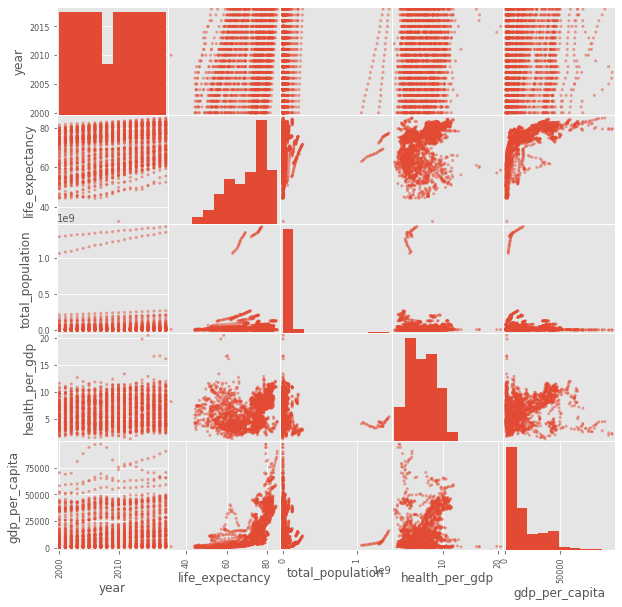

```python
pd.plotting.scatter_matrix(gapminder_data,figsize=(10,10));
```

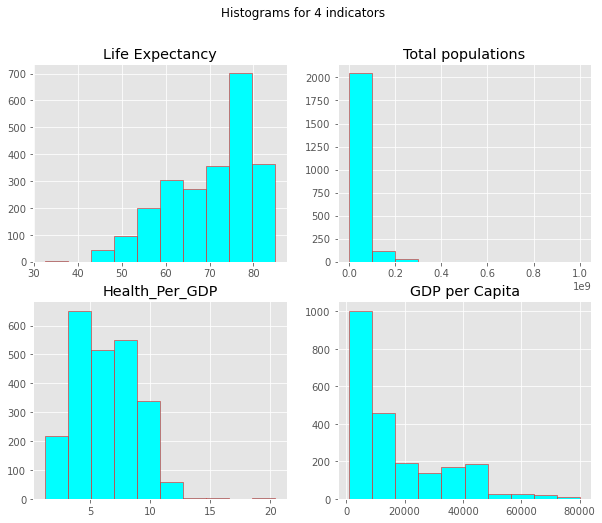

```python
#Histogram for all 4 indicators to show the distribution of data in each one

fig,((axs1,axs2),(axs3,axs4))=plt.subplots(2,2)
fig.suptitle("Histograms for 4 indicators")
fig.set_figheight(8)
fig.set_figwidth(10)
axs1.hist(gapminder_data.life_expectancy,facecolor="cyan",edgecolor="red",bins=10)
axs1.set_title("Life Expectancy")
axs2.hist(gapminder_data.total_population,facecolor="cyan",edgecolor="red",bins=10,range=(1000000,1000000000))
axs2.set_title("Total populations")
axs3.hist(gapminder_data.health_per_gdp,facecolor="cyan",edgecolor="red",bins=10);
axs3.set_title("Health_Per_GDP")
axs4.hist(gapminder_data.gdp_per_capita,facecolor="cyan",edgecolor="red",bins=10,range=(1000,80000));
axs4.set_title("GDP per Capita");
```

#### it looks like the data in total populations and GDP per capita are right skewed

#### there is ouliers in health per GDP

## Q1 performance of each continent in all indicators

```python
# heighest continents in each indicator:

## 1- life expectanct

conti_life_exp=gapminder_data.groupby("continent",as_index=False)["life_expectancy"].mean().sort_values("life_expectancy",ascending=False)

## 2- total population

conti_total_pop=gapminder_data.groupby(["continent"],as_index=False)["total_population"].mean().sort_values("total_population",ascending=False)


### 3-GDP per capita

conti_gdp_capita=gapminder_data.groupby("continent",as_index=False)["gdp_per_capita"].mean().round().sort_values("gdp_per_capita",ascending=False)

#### 4- Health per GDP

conti_health_per_capita=gapminder_data.groupby("continent",as_index=False)["health_per_gdp"].mean().sort_values("health_per_gdp",ascending=False)


##### displaying all datafram for continent
display_side_by_side([conti_life_exp,conti_total_pop,conti_gdp_capita,conti_health_per_capita],["Continent per Life expectation mean","Continent per Total population mean","Continent per GDP per Capita mean","Continent per health per capita mean"])
```

Continent per Life expectation mean

|  | continent | life_expectancy |
| --- | --- | --- |
| 4 | Oceania | 80.926316 |
| 3 | Europe | 78.589474 |
| 1 | Americas | 75.069674 |
| 2 | Asia | 72.698381 |
| 0 | Africa | 60.907602 |

Continent per Total population mean

|  | continent | total_population |
| --- | --- | --- |
| 2 | Asia | 145097194.309717 |
| 1 | Americas | 27241228.060150 |
| 3 | Europe | 20253206.865699 |
| 0 | Africa | 19311316.934503 |
| 4 | Oceania | 13053947.315789 |

Continent per GDP per Capita mean

|  | continent | gdp_per_capita |
| --- | --- | --- |
| 4 | Oceania | 36779.000000 |
| 3 | Europe | 31568.000000 |
| 2 | Asia | 19006.000000 |
| 1 | Americas | 12748.000000 |
| 0 | Africa | 4976.000000 |

Continent per health per capita mean

|  | continent | health_per_gdp |
| --- | --- | --- |
| 4 | Oceania | 8.615789 |
| 3 | Europe | 8.344192 |
| 1 | Americas | 7.048195 |
| 0 | Africa | 5.544175 |
| 2 | Asia | 4.736255 |

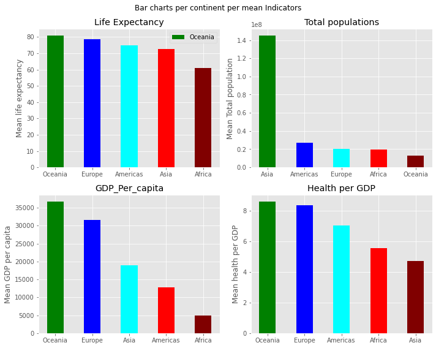

```python
## visualizations for continent in each indicator

plt.style.use("ggplot")

fig,((axs1,axs2),(axs3,axs4))=plt.subplots(2,2)
fig.suptitle("Bar charts per continent per mean Indicators")
fig.set_figheight(8)
fig.set_figwidth(10)

color=["green","blue","cyan","red","maroon"]

# bar for life expectancy

x1=conti_life_exp.continent.values
y1=conti_life_exp.life_expectancy.values
life=axs1.bar(x1,y1,width=0.45,color=color)
axs1.set_title("Life Expectancy")
axs1.set_ylabel("Mean life expectancy")
axs1.legend(x1)
# bar for total populations

x2=conti_total_pop.continent.values
y2=conti_total_pop.total_population.values

axs2.bar(x2,y2,width=0.45,color=color)
axs2.set_title("Total populations")
axs2.set_ylabel("Mean Total population")


### bar for gdp per capita

x3=conti_gdp_capita.continent.values
y3=conti_gdp_capita.gdp_per_capita.values

axs3.bar(x3,y3,width=0.45,color=color)
axs3.set_title("GDP_Per_capita")
axs3.set_ylabel("Mean GDP per capita")

### bar for health per gdp

x4=conti_health_per_capita.continent.values
y4=conti_health_per_capita.health_per_gdp.values

axs4.bar(x4,y4,width=0.45,color=color)
axs4.set_title("Health per GDP")
axs4.set_ylabel("Mean health per GDP")


plt.tight_layout()
plt.show()
```

#### Oceania is the heighest continent in all 4 indicators except total population (Asia is the highest population number )

# Q2 top 10 countries performance in each indicator

```python
# top ten countries

#1- life expectancy

life_exp_mean=gapminder_data.groupby(["country"],as_index=False)["life_expectancy"].mean()

top10_life_exp_countries=life_exp_mean.sort_values("life_expectancy",ascending=False).head(10)


##2- total population

total_pop_mean=gapminder_data.groupby(["country"],as_index=False)["total_population"].mean()

top10_total_pop_countries=total_pop_mean.sort_values("total_population",ascending=False).head(10)

###3- GDP per capita

gdp_capita_mean=gapminder_data.groupby(["country"],as_index=False)["gdp_per_capita"].mean()

top10_gdp_capita_countries=gdp_capita_mean.sort_values("gdp_per_capita",ascending=False).head(10)

####4- Health per GDP

health_gdp_mean=gapminder_data.groupby(["country"],as_index=False)["health_per_gdp"].mean()

top10_health_per_gdp_countries=health_gdp_mean.sort_values("health_per_gdp",ascending=False).head(10)

display_side_by_side([top10_life_exp_countries,top10_total_pop_countries,top10_gdp_capita_countries,top10_health_per_gdp_countries],["Top 10 life exp countries","Top 10 Total population countries","Top 10 countries in GDP per capita(in US$)","Top 10 countries spending on health(% to GDP)"])
```

Top 10 life exp countries

|  | country | life_expectancy |
| --- | --- | --- |
| 61 | Japan | 82.994737 |
| 104 | Singapore | 82.484211 |
| 111 | Switzerland | 82.257895 |
| 52 | Iceland | 81.936842 |
| 59 | Italy | 81.610526 |
| 5 | Australia | 81.568421 |
| 107 | Spain | 81.452632 |
| 110 | Sweden | 81.221053 |
| 40 | France | 81.178947 |
| 58 | Israel | 81.078947 |

Top 10 Total population countries

|  | country | total_population |
| --- | --- | --- |
| 23 | China | 1361052631.578947 |
| 53 | India | 1212631578.947368 |
| 54 | Indonesia | 239052631.578947 |
| 13 | Brazil | 193263157.894737 |
| 90 | Pakistan | 176105263.157895 |
| 87 | Nigeria | 156105263.157895 |
| 8 | Bangladesh | 145578947.368421 |
| 61 | Japan | 128105263.157895 |
| 75 | Mexico | 112468421.052632 |
| 94 | Philippines | 92552631.578947 |

Top 10 countries in GDP per capita(in US$)

|  | country | gdp_per_capita |
| --- | --- | --- |
| 64 | Kuwait | 78505.263158 |
| 104 | Singapore | 70189.473684 |
| 88 | Norway | 62605.157895 |
| 111 | Switzerland | 54931.578947 |
| 57 | Ireland | 48942.105263 |
| 100 | Saudi Arabia | 46342.105263 |
| 83 | Netherlands | 45568.421053 |
| 30 | Denmark | 44731.578947 |
| 6 | Austria | 42884.210526 |
| 7 | Bahrain | 42700.000000 |

Top 10 countries spending on health(% to GDP)

|  | country | health_per_gdp |
| --- | --- | --- |
| 103 | Sierra Leone | 12.835263 |
| 40 | France | 10.772632 |
| 43 | Germany | 10.656316 |
| 111 | Switzerland | 10.521579 |
| 6 | Austria | 9.911053 |
| 28 | Cuba | 9.894737 |
| 19 | Canada | 9.863684 |
| 9 | Belgium | 9.694737 |
| 0 | Afghanistan | 9.668421 |
| 30 | Denmark | 9.603684 |

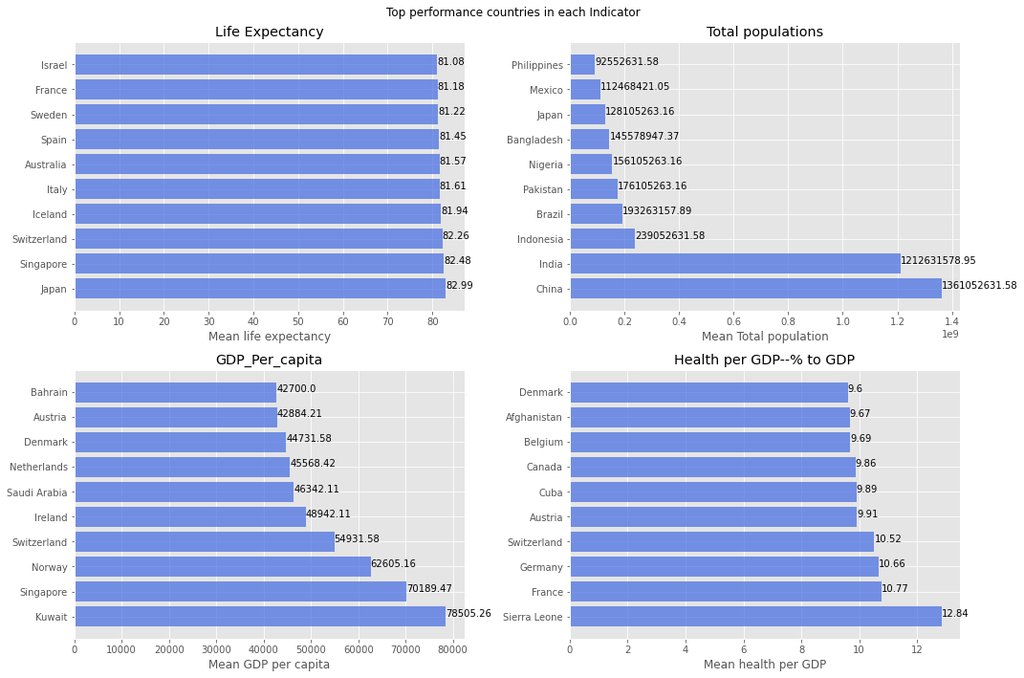

```python
plt.style.use("ggplot")

fig,((axs1,axs2),(axs3,axs4))=plt.subplots(2,2)
fig.suptitle("Top performance countries in each Indicator")
fig.set_figheight(10)
fig.set_figwidth(15)

color='royalblue'

# bar for life expectancy

x1=top10_life_exp_countries.country.values
y1=top10_life_exp_countries.life_expectancy.values
axs1.barh(x1,y1,color=color,alpha=0.7)
axs1.set_title("Life Expectancy")
axs1.set_xlabel("Mean life expectancy")
for i, v in enumerate(y1):
    axs1.text(v , i , str(round(v,2)),color = 'black')


# bar for total populations

x2=top10_total_pop_countries.country.values
y2=top10_total_pop_countries.total_population.values

axs2.barh(x2,y2,color=color,alpha=0.7)
axs2.set_title("Total populations")
axs2.set_xlabel("Mean Total population")
for i, v in enumerate(y2):
    axs2.text(v , i , str(round(v,2)),color = 'black')


### bar for gdp per capita

x3=top10_gdp_capita_countries.country.values
y3=top10_gdp_capita_countries.gdp_per_capita.values

axs3.barh(x3,y3,color=color,alpha=0.7)
axs3.set_title("GDP_Per_capita")
axs3.set_xlabel("Mean GDP per capita")
for i, v in enumerate(y3):
    axs3.text(v , i , str(round(v,2)),color = 'black')

### bar for health per gdp

x4=top10_health_per_gdp_countries.country.values
y4=top10_health_per_gdp_countries.health_per_gdp.values

axs4.barh(x4,y4,color=color,alpha=0.7)
axs4.set_title("Health per GDP--% to GDP")
axs4.set_xlabel("Mean health per GDP")
for i, v in enumerate(y4):
    axs4.text(v , i , str(round(v,2)),color = 'black')

plt.tight_layout()
plt.show()
```

### 1- life expectancy : Japan is the heighst country

### 2-Total population : China

### 3-GDP per capita : Kuwait

### 4-Health per GDP : Sierra leone

# Q3 Bottom 10 countries performance in each indicator

```python
# Bottom ten countries

#1- life expectancy

life_exp_mean=gapminder_data.groupby(["country"],as_index=False)["life_expectancy"].mean()

bottom10_life_exp_countries=life_exp_mean.sort_values("life_expectancy",ascending=False).tail(10)


##2- total population

total_pop_mean=gapminder_data.groupby(["country"],as_index=False)["total_population"].mean()

bottom10_total_pop_countries=total_pop_mean.sort_values("total_population",ascending=False).tail(10)

###3- GDP per capita

gdp_capita_mean=gapminder_data.groupby(["country"],as_index=False)["gdp_per_capita"].mean()

bottom10_gdp_capita_countries=gdp_capita_mean.sort_values("gdp_per_capita",ascending=False).tail(10)

####4- Health per GDP

health_gdp_mean=gapminder_data.groupby(["country"],as_index=False)["health_per_gdp"].mean()

bottom10_health_per_gdp_countries=health_gdp_mean.sort_values("health_per_gdp",ascending=False).tail(10)

display_side_by_side([bottom10_life_exp_countries,bottom10_total_pop_countries,bottom10_gdp_capita_countries,bottom10_health_per_gdp_countries],["Bottom 10 life exp countries","Bottom 10 Total population countries","Bottom 10 countries in GDP per capita","Bottom 10 countries spending on health--% to GDP--"])
```

Bottom 10 life exp countries

|  | country | life_expectancy |
| --- | --- | --- |
| 21 | Chad | 55.900000 |
| 48 | Guinea-Bissau | 55.684211 |
| 103 | Sierra Leone | 55.184211 |
| 16 | Burundi | 55.063158 |
| 121 | Zambia | 54.668421 |
| 70 | Malawi | 53.505263 |
| 79 | Mozambique | 52.905263 |
| 122 | Zimbabwe | 51.278947 |
| 66 | Lesotho | 48.205263 |
| 20 | Central African Republic | 47.578947 |

Bottom 10 Total population countries

|  | country | total_population |
| --- | --- | --- |
| 48 | Guinea-Bissau | 1503684.210526 |
| 115 | Trinidad and Tobago | 1324736.842105 |
| 74 | Mauritius | 1236315.789474 |
| 7 | Bahrain | 1117578.947368 |
| 36 | Equatorial Guinea | 923157.894737 |
| 31 | Djibouti | 834052.631579 |
| 25 | Comoros | 678842.105263 |
| 77 | Montenegro | 621315.789474 |
| 52 | Iceland | 311157.894737 |
| 99 | Sao Tome and Principe | 175315.789474 |

Bottom 10 countries in GDP per capita

|  | country | gdp_per_capita |
| --- | --- | --- |
| 98 | Rwanda | 1352.473684 |
| 114 | Togo | 1287.894737 |
| 103 | Sierra Leone | 1221.736842 |
| 67 | Liberia | 1138.315789 |
| 38 | Ethiopia | 1071.578947 |
| 70 | Malawi | 1002.473684 |
| 79 | Mozambique | 911.000000 |
| 20 | Central African Republic | 845.947368 |
| 86 | Niger | 824.631579 |
| 16 | Burundi | 715.842105 |

Bottom 10 countries spending on health--% to GDP--

|  | country | health_per_gdp |
| --- | --- | --- |
| 31 | Djibouti | 3.124737 |
| 89 | Oman | 3.086316 |
| 3 | Angola | 2.972632 |
| 41 | Gabon | 2.960526 |
| 10 | Benin | 2.927895 |
| 80 | Myanmar | 2.900526 |
| 90 | Pakistan | 2.730000 |
| 54 | Indonesia | 2.669474 |
| 8 | Bangladesh | 2.332105 |
| 36 | Equatorial Guinea | 2.073684 |

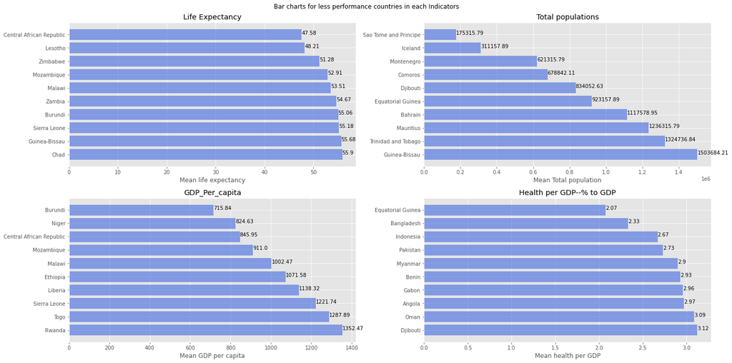

```python
plt.style.use("ggplot")

fig,((axs1,axs2),(axs3,axs4))=plt.subplots(2,2)
fig.suptitle("Bar charts for less performance countries in each Indicators")
fig.set_figheight(10)
fig.set_figwidth(20)

color='royalblue'
alpha=0.6
# bar for life expectancy

x1=bottom10_life_exp_countries.country.values
y1=bottom10_life_exp_countries.life_expectancy.values
axs1.barh(x1,y1,color=color,alpha=alpha)
axs1.set_title("Life Expectancy")
axs1.set_xlabel("Mean life expectancy")
for i, v in enumerate(y1):
    axs1.text(v , i , str(round(v,2)),color = 'black')



# bar for total populations

x2=bottom10_total_pop_countries.country.values
y2=bottom10_total_pop_countries.total_population.values

axs2.barh(x2,y2,color=color,alpha=alpha)
axs2.set_title("Total populations")
axs2.set_xlabel("Mean Total population")
for i, v in enumerate(y2):
    axs2.text(v , i , str(round(v,2)),color = 'black')


### bar for gdp per capita

x3=bottom10_gdp_capita_countries.country.values
y3=bottom10_gdp_capita_countries.gdp_per_capita.values

axs3.barh(x3,y3,color=color,alpha=alpha)
axs3.set_title("GDP_Per_capita")
axs3.set_xlabel("Mean GDP per capita")
for i, v in enumerate(y3):
    axs3.text(v , i , str(round(v,2)),color = 'black')

### bar for health per gdp

x4=bottom10_health_per_gdp_countries.country.values
y4=bottom10_health_per_gdp_countries.health_per_gdp.values

axs4.barh(x4,y4,color=color,alpha=alpha)
axs4.set_title("Health per GDP--% to GDP")
axs4.set_xlabel("Mean health per GDP")
for i, v in enumerate(y4):
    axs4.text(v , i , str(round(v,2)),color = 'black')

plt.tight_layout()
plt.show()
```

### 1-life expectancy : Central African Republic is the least one

### 2-Total population: san tome principe

### 3-GDP per capita :Burundi

### 4-Health per GDP :Equatorial Guinea

# Q4 Egypt performance analysis

```python
egy_data=gapminder_data.query('country=="Egypt"')
```

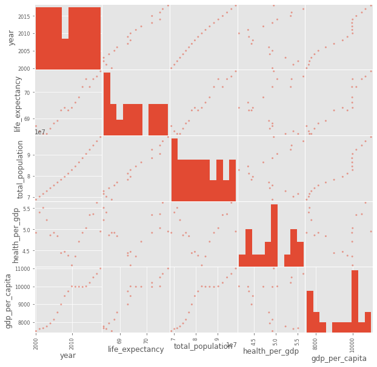

```python
pd.plotting.scatter_matrix(egy_data,figsize=(10,10));
```

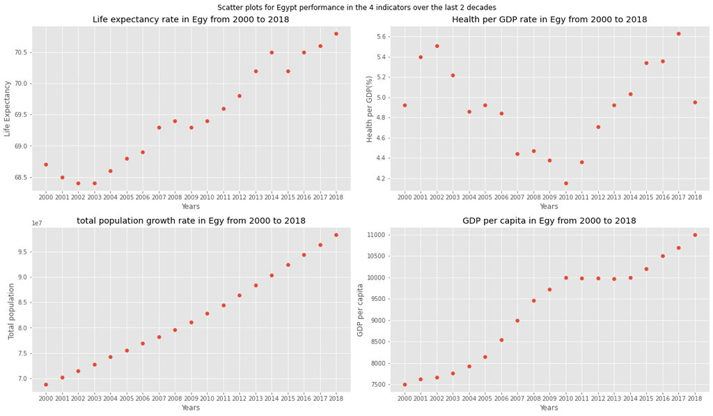

```python
#scatter plots for all 4 indicators over years

fig,((ax1,ax2),(ax3,ax4))=plt.subplots(2,2)
fig.suptitle("Scatter plots for Egypt performance in the 4 indicators over the last 2 decades")
fig.set_figheight(10)
fig.set_figwidth(17)

x=[]
for a in range(2000,2019,1):
    x.append(str(a))

ax1.scatter(x=x,y=egy_data.life_expectancy)
ax1.set_title("Life expectancy rate in Egy from 2000 to 2018")
ax1.set_ylabel("Life Expectancy")
ax1.set_xlabel("Years")



ax2.scatter(x=x,y=egy_data.health_per_gdp)
ax2.set_title("Health per GDP rate in Egy from 2000 to 2018")
ax2.set_ylabel("Health per GDP(%)")
ax2.set_xlabel("Years")

ax3.scatter(x=x,y=egy_data.total_population)
ax3.set_title("total population growth rate in Egy from 2000 to 2018")
ax3.set_ylabel("Total population ")
ax3.set_xlabel("Years")

ax4.scatter(x=x,y=egy_data.gdp_per_capita)
ax4.set_title("GDP per capita in Egy from 2000 to 2018")
ax4.set_ylabel("GDP per capita")
ax4.set_xlabel("Years")

plt.tight_layout()
plt.show()
```

#### Answer 4

##### a quick look at plots reveal that the performance in spending on health is very variance in the last 18 years it reached to its high level between 2015-2017 then begin to decline in 2018

##### about GDP per capita it incresing overtime except a period of steady state between 2010 and 2014

# Q5 correlations between indicators

### 1- correlation between life expectancy and health per GDp

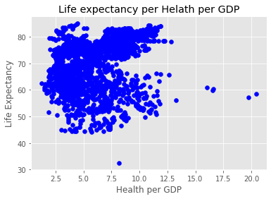

```python
#correlation between life expectancy and gdp per capita for all data sets

x=gapminder_data.health_per_gdp.values
y=gapminder_data.life_expectancy.values
plt.scatter(x,y,color="b")
plt.title("Life expectancy per Helath per GDP")
plt.ylabel("Life Expectancy")
plt.xlabel("Health per GDP")
plt.show()
```

#### it looks like there isn't any realtion here

#### but what if we choose the expectancy life rate >70 is it any relations??

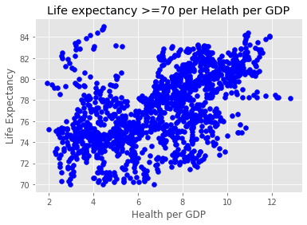

```python
# filtering data to choose the life expectancy above 70 years age

life_exp_above70=gapminder_data.query('life_expectancy >= 70')

x=life_exp_above70.health_per_gdp.values
y=life_exp_above70.life_expectancy.values
plt.scatter(x,y,color="b")
plt.title("Life expectancy >=70 per Helath per GDP")
plt.ylabel("Life Expectancy")
plt.xlabel("Health per GDP")
plt.show()
```

### it looks like there is trending here

### 2- correlation between GDP per capita and life expectancy

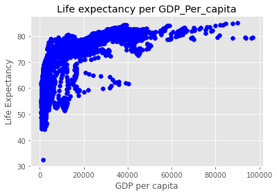

```python
x=gapminder_data.gdp_per_capita.values
y=gapminder_data.life_expectancy.values
plt.scatter(x,y,color="b")
plt.title("Life expectancy per GDP_Per_capita")
plt.ylabel("Life Expectancy")
plt.xlabel("GDP per capita")
plt.show()
```

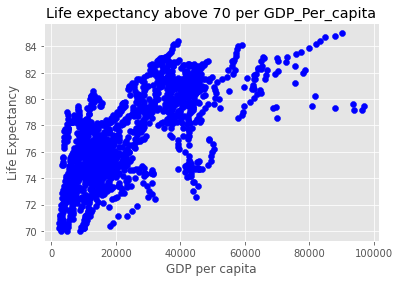

```python
x=life_exp_above70.gdp_per_capita.values
y=life_exp_above70.life_expectancy.values
plt.scatter(x,y,color="b")
plt.title("Life expectancy above 70 per GDP_Per_capita")
plt.ylabel("Life Expectancy")
plt.xlabel("GDP per capita")
plt.show()
```

### There is a positive correlation between life expectancy above 70 and GDP per capita

## Q6: what is the variance between income level over the year?

```python
# grouping the data according to GDP per capita per countries to:

##1-low income countries (GDP per capita <= 1025 $)
##2-lower_middle income countries (GDP per capita between 1026 and 3995 $)
##3-upper_middle income countries (GDP per capita 3996 to 12375)
##3-higher income >= 12376

lower_income=gdp_per_capita2.query('gdp_per_capita <= 1025')
lower_middel_income=gdp_per_capita2.query('3995 >=gdp_per_capita > 1025')
upper_middle_income=gdp_per_capita2.query('12375 >=gdp_per_capita >=3996')
higher_income=gdp_per_capita2.query('gdp_per_capita >=12376')
```

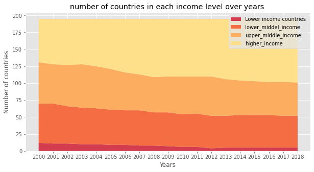

```python
#plotting the data to show the change in numbers of countries in each category

fig = plt.figure(figsize=(10,5))

x=[]
for a in range(2000,2019,1):
    x.append(str(a))

y1=lower_income.groupby("year")["country"].count()
y2=lower_middel_income.groupby("year")["country"].count()
y3=upper_middle_income.groupby("year")["country"].count()
y4=higher_income.groupby("year")["country"].count()

labels=["Lower income countries","lower_middel_income","upper_middle_income","higher_income"]
palette = sns.color_palette("Spectral", 9).as_hex()
colors = ','.join(palette)


plt.stackplot(x,y1,y2,y3,y4,labels=labels,colors=colors)
plt.legend(loc = 0)
plt.title("number of countries in each income level over years ")
plt.xlabel("Years")
plt.ylabel("Number of countries")


plt.show()
```

### There is a gradual decreasing in number of countries with lower income level and increasing in number of countries with high income level over the last 2 decades

## Q7 : lets try to spot the heighst performance country through all indicators and analyze it in details

```python
## it seems that Singapore is one of the most countries performance

gapminder_data.sort_values(["life_expectancy","total_population","gdp_per_capita","health_per_gdp"],ascending=False)
```

|  | country | continent | year | life_expectancy | total_population | health_per_gdp | gdp_per_capita |
| --- | --- | --- | --- | --- | --- | --- | --- |
| 23928 | Singapore | Asia | 2018 | 85.0 | 5760000 | 4.46 | 90100 |
| 23916 | Singapore | Asia | 2017 | 84.8 | 5710000 | 4.42 | 87800 |
| 23904 | Singapore | Asia | 2016 | 84.7 | 5650000 | 4.40 | 84700 |
| 14124 | Japan | Asia | 2018 | 84.4 | 127000000 | 10.95 | 39300 |
| 23892 | Singapore | Asia | 2015 | 84.4 | 5590000 | 4.18 | 83300 |
| ... | ... | ... | ... | ... | ... | ... | ... |
| 15108 | Lesotho | Africa | 2005 | 44.4 | 2000000 | 5.07 | 1910 |
| 4572 | Central African Republic | Africa | 2001 | 44.3 | 3720000 | 3.95 | 869 |
| 4560 | Central African Republic | Africa | 2000 | 44.3 | 3640000 | 4.33 | 851 |
| 15120 | Lesotho | Africa | 2006 | 44.2 | 1990000 | 5.69 | 2000 |
| 11292 | Haiti | Americas | 2010 | 32.5 | 9950000 | 8.15 | 1510 |

2337 rows × 7 columns

```python
singapore=gapminder_data.query('country=="Singapore"')
```

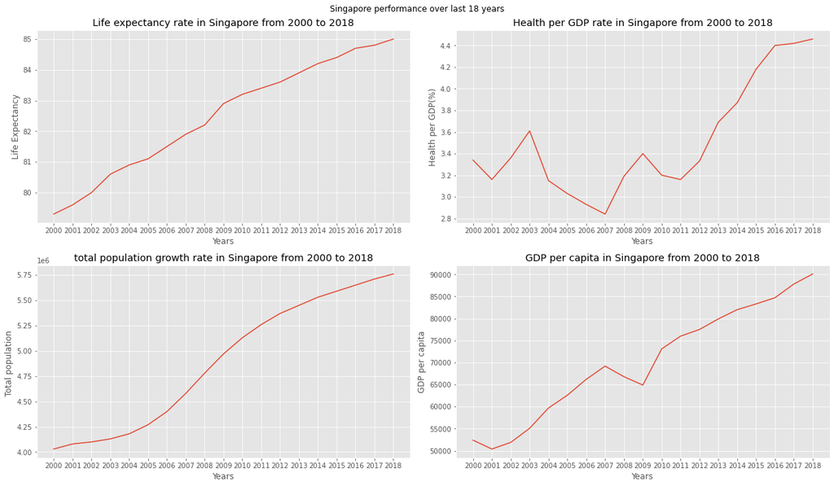

```python
fig,((ax1,ax2),(ax3,ax4))=plt.subplots(2,2)
fig.suptitle("Singapore performance over last 18 years")
fig.set_figheight(10)
fig.set_figwidth(17)

x=[]
for a in range(2000,2019,1):
    x.append(str(a))

ax1.plot(x,singapore.life_expectancy)
ax1.set_title("Life expectancy rate in Singapore from 2000 to 2018")
ax1.set_ylabel("Life Expectancy")
ax1.set_xlabel("Years")



ax2.plot(x,singapore.health_per_gdp)
ax2.set_title("Health per GDP rate in Singapore from 2000 to 2018")
ax2.set_ylabel("Health per GDP(%)")
ax2.set_xlabel("Years")

ax3.plot(x,singapore.total_population)
ax3.set_title("total population growth rate in Singapore from 2000 to 2018")
ax3.set_ylabel("Total population ")
ax3.set_xlabel("Years")

ax4.plot(x,singapore.gdp_per_capita)
ax4.set_title("GDP per capita in Singapore from 2000 to 2018")
ax4.set_ylabel("GDP per capita")
ax4.set_xlabel("Years")

plt.tight_layout()
plt.show()
```

### It looks like Singapore is one of the best country performance in the last two decades specially in GDP per capita

## Q8 : what are the indicators that most affect the happiness score?

```python
## now it is time to merge the dependent variable (happiness_score) to see how other varables affect it

gapminder_data_2=pd.merge(left=gapminder_data,right=happiness_s,how="inner",on=["country"],copy=True)

gapminder_data_2.head()
```

|  | country | continent | year | life_expectancy | total_population | health_per_gdp | gdp_per_capita | Year | happiness_score |
| --- | --- | --- | --- | --- | --- | --- | --- | --- | --- |
| 0 | Afghanistan | Asia | 2000 | 54.6 | 20800000 | 9.67 | 687 | 2005 | 37.04 |
| 1 | Afghanistan | Asia | 2000 | 54.6 | 20800000 | 9.67 | 687 | 2006 | 37.04 |
| 2 | Afghanistan | Asia | 2000 | 54.6 | 20800000 | 9.67 | 687 | 2007 | 37.04 |
| 3 | Afghanistan | Asia | 2000 | 54.6 | 20800000 | 9.67 | 687 | 2008 | 37.20 |
| 4 | Afghanistan | Asia | 2000 | 54.6 | 20800000 | 9.67 | 687 | 2009 | 44.00 |

```python
#check for duplicate

gapminder_data_2
```

|  | country | continent | year | life_expectancy | total_population | health_per_gdp | gdp_per_capita | Year | happiness_score |
| --- | --- | --- | --- | --- | --- | --- | --- | --- | --- |
| 0 | Afghanistan | Asia | 2000 | 54.6 | 20800000 | 9.67 | 687 | 2005 | 37.04 |
| 1 | Afghanistan | Asia | 2000 | 54.6 | 20800000 | 9.67 | 687 | 2006 | 37.04 |
| 2 | Afghanistan | Asia | 2000 | 54.6 | 20800000 | 9.67 | 687 | 2007 | 37.04 |
| 3 | Afghanistan | Asia | 2000 | 54.6 | 20800000 | 9.67 | 687 | 2008 | 37.20 |
| 4 | Afghanistan | Asia | 2000 | 54.6 | 20800000 | 9.67 | 687 | 2009 | 44.00 |
| ... | ... | ... | ... | ... | ... | ... | ... | ... | ... |
| 31649 | Zimbabwe | Africa | 2018 | 61.7 | 14400000 | 4.73 | 2620 | 2014 | 41.80 |
| 31650 | Zimbabwe | Africa | 2018 | 61.7 | 14400000 | 4.73 | 2620 | 2015 | 37.00 |
| 31651 | Zimbabwe | Africa | 2018 | 61.7 | 14400000 | 4.73 | 2620 | 2016 | 37.40 |
| 31652 | Zimbabwe | Africa | 2018 | 61.7 | 14400000 | 4.73 | 2620 | 2017 | 36.40 |
| 31653 | Zimbabwe | Africa | 2018 | 61.7 | 14400000 | 4.73 | 2620 | 2018 | 36.20 |

31654 rows × 9 columns

```python
#check for any null data

gapminder_data_2.isnull().any()
```

```
country             False
continent           False
year                False
life_expectancy     False
total_population    False
health_per_gdp      False
gdp_per_capita      False
Year                False
happiness_score     False
dtype: bool
```

```python
## check data types

gapminder_data_2.dtypes
```

```
country              object
continent            object
year                  int64
life_expectancy     float64
total_population      int64
health_per_gdp      float64
gdp_per_capita        int64
Year                  int64
happiness_score     float64
dtype: object
```

```python
# describtive statistics

gapminder_data_2.describe()
```

|  | year | life_expectancy | total_population | health_per_gdp | gdp_per_capita | Year | happiness_score |
| --- | --- | --- | --- | --- | --- | --- | --- |
| count | 31654.000000 | 31654.000000 | 3.165400e+04 | 31654.000000 | 31654.000000 | 31654.000000 | 31654.000000 |
| mean | 2009.000000 | 70.631004 | 4.891967e+07 | 6.361530 | 16305.828395 | 2011.500000 | 53.830720 |
| std | 5.477312 | 9.462139 | 1.675307e+08 | 2.479463 | 16894.015043 | 4.031193 | 11.810144 |
| min | 2000.000000 | 32.500000 | 2.800000e+05 | 1.700000 | 573.000000 | 2005.000000 | 26.600000 |
| 25% | 2004.000000 | 63.500000 | 4.950000e+06 | 4.230000 | 2860.000000 | 2008.000000 | 44.400000 |
| 50% | 2009.000000 | 74.000000 | 1.120000e+07 | 6.190000 | 10400.000000 | 2011.500000 | 52.145000 |
| 75% | 2014.000000 | 78.100000 | 3.230000e+07 | 8.280000 | 25300.000000 | 2015.000000 | 62.920000 |
| max | 2018.000000 | 85.000000 | 1.430000e+09 | 20.410000 | 96800.000000 | 2018.000000 | 80.200000 |

```python
##the happiest 10 countries

happiness=gapminder_data_2.groupby("country",as_index=False)["happiness_score"].mean()
happiness.sort_values("happiness_score",ascending=False).head(10)
```

|  | country | happiness_score |
| --- | --- | --- |
| 30 | Denmark | 76.915714 |
| 37 | Finland | 75.527857 |
| 85 | Norway | 75.488571 |
| 107 | Switzerland | 75.338571 |
| 80 | Netherlands | 74.650000 |
| 19 | Canada | 74.238571 |
| 49 | Iceland | 74.118571 |
| 106 | Sweden | 73.722857 |
| 81 | New Zealand | 73.241429 |
| 5 | Australia | 72.991429 |

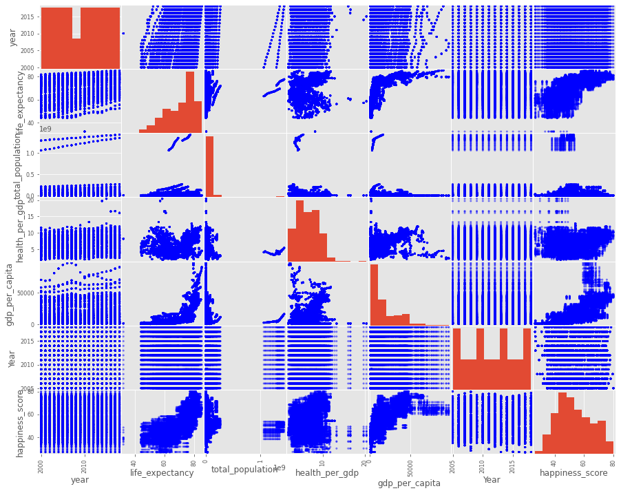

```python
pd.plotting.scatter_matrix(gapminder_data_2,figsize=(15,12),color="blue");
```

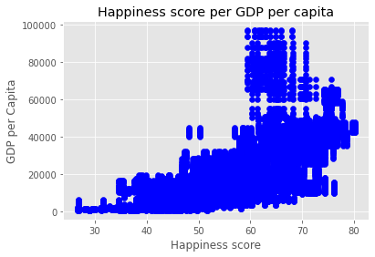

```python
##scatter plots between hapiness score and each indicator

x=gapminder_data_2.happiness_score.values
y=gapminder_data_2.gdp_per_capita.values
plt.scatter(x,y,color="b")
plt.title("Happiness score per GDP per capita")
plt.ylabel("GDP per Capita")
plt.xlabel("Happiness score")
plt.show()
```

### It seems there is a positive relation between happiness and the person income but may be it is different in high income (Above 60,000 dollars) !!!! lets deep dive in this point

```python
# we will divide data of gdp per capita into 2 sets above 60000 and below 60000

gdp_above_60=gapminder_data_2.query('gdp_per_capita >=60000')
gdp_below_60=gapminder_data_2.query('gdp_per_capita <= 60000')
```

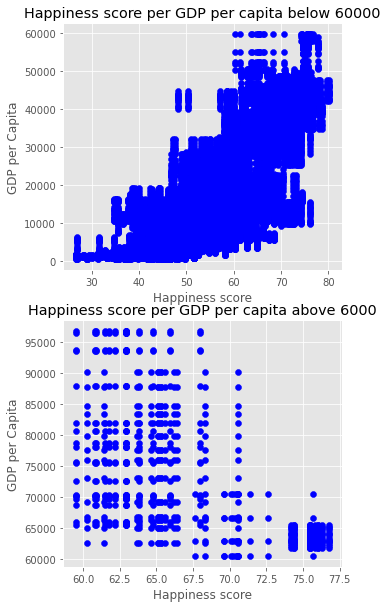

```python
fig,(ax1,ax2)=plt.subplots(2)
fig.suptitle("")
fig.set_figheight(10)
fig.set_figwidth(5)

x1=gdp_below_60.happiness_score.values
y1=gdp_below_60.gdp_per_capita.values
ax1.scatter(x1,y1,color="b")
ax1.set_title("Happiness score per GDP per capita below 60000")
ax1.set_ylabel("GDP per Capita")
ax1.set_xlabel("Happiness score")

x2=gdp_above_60.happiness_score.values
y2=gdp_above_60.gdp_per_capita.values
ax2.scatter(x2,y2,color="b")
ax2.set_title("Happiness score per GDP per capita above 6000")
ax2.set_ylabel("GDP per Capita")
ax2.set_xlabel("Happiness score")


plt.show()
```

###### in GDP per capita above 60000 there is no correlation unlike GDP per capita below 6000 which is a strong positive correlation

### the second correlation between happiness score and life expectancy

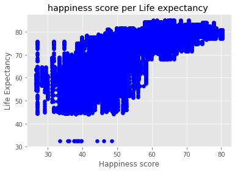

```python
x=gapminder_data_2.happiness_score.values
y=gapminder_data_2.life_expectancy.values
plt.scatter(x,y,color="b")
plt.title("happiness score per Life expectancy ")
plt.ylabel("Life Expectancy")
plt.xlabel("Happiness score")
plt.show()
```

### There is a possitive correlation between happiness score and life expectancy

# Conclusions:

### Limitation of data :

- There was alot of missing data specially in happiness score data and this affect on findings and building a clear correlations
- also there is limitied data in some indicators like (health per GDP ) only data from 2000 to 2018 are available